# Association between variables

Vladislav Stanin

01/24/2024

# Two dichotomous variables (2 x 2 table)

|  | Cured | Dead | *Row Total* |
| --- | --- | --- | --- |
| **Treatment** | 12 | 8 | 20 |
| **Placebo** | 6 | 10 | 16 |
| *Column Total* | 18 | 18 | **36** |

```r
data_cure = data.frame(
  Patient_ID = 1:36,
  Group = factor(c(rep("Treatment", 12), rep("Placebo", 6), rep("Treatment", 8), rep("Placebo", 10))),
  Outcome = factor(rep(c('Cured', 'Dead'), e=18)))

data_cure %>%  head()
```

```
##   Patient_ID     Group Outcome
## 1          1 Treatment   Cured
## 2          2 Treatment   Cured
## 3          3 Treatment   Cured
## 4          4 Treatment   Cured
## 5          5 Treatment   Cured
## 6          6 Treatment   Cured
```

```r
contingency_table = table(data_cure$Group, data_cure$Outcome)
contingency_table
```

```
##
##             Cured Dead
##   Placebo       6   10
##   Treatment    12    8
```

```r
contingency_table_big = addmargins(contingency_table)
contingency_table_big
```

```
##
##             Cured Dead Sum
##   Placebo       6   10  16
##   Treatment    12    8  20
##   Sum          18   18  36
```

## Risk ratio ($RR$)

$Risk_{tr}$ (to be dead in case of treatment) = $\dfrac{Dead | Treatment}{Total\ Treatment}$

```r
risk_tr = contingency_table_big['Treatment', 'Dead']/ contingency_table_big['Treatment', 'Sum']
risk_tr
```

```
## [1] 0.4
```

$Risk_{pl}$ (to be dead in case of Placebo) = $\dfrac{Dead | Placebo}{Total\ Placebo}$ =

```r
risk_pl = contingency_table_big['Placebo', 'Dead']/ contingency_table_big['Placebo', 'Sum']
risk_pl
```

```
## [1] 0.625
```

Risk ratio ($RR$) = $\dfrac{Risk_{pl}}{Risk_{tr}} =$

```r
RR = risk_pl / risk_tr
RR
```

```
## [1] 1.5625
```

There is some association between Treatment and Result - Placebo patients tend to be dead more often.

**NB! The group we are comparing with is usually in the denominator!**

### **If there were more cured:**

```r
risk_tr_1 = contingency_table_big['Treatment', 'Dead'] / 1020
risk_tr_1
```

```
## [1] 0.007843137
```

```r
risk_pl_1 = contingency_table_big['Placebo', 'Dead'] / 1016
risk_pl_1
```

```
## [1] 0.00984252
```

```r
RR = risk_pl_1 / risk_tr_1
RR
```

```
## [1] 1.254921
```

Almost the same $RR$, despite big number of cured!

## Risk difference ($RD$)

> *Use variables created above*

```r
RD = risk_pl - risk_tr
RD
```

```
## [1] 0.225
```

### **And if there are more Cured:**

```r
RD = risk_pl_1 - risk_tr_1
RD
```

```
## [1] 0.001999382
```

**-> Always show both RR and RD in your text!**

## Odds ratio ($OR$)

$Odds_{tr} = \dfrac{Dead | Treatment}{Cured | Treatment} =$

```r
odds_tr = contingency_table_big['Treatment', 'Dead'] / contingency_table_big['Treatment', 'Cured']
odds_tr
```

```
## [1] 0.6666667
```

$Odds_{pl} = \dfrac{Dead | Placebo}{Cured | Placebo} =$

```r
odds_pl = contingency_table_big['Placebo', 'Dead'] / contingency_table_big['Placebo', 'Cured']
odds_pl
```

```
## [1] 1.666667
```

$Odds \ ratio \ (OR) = \dfrac{Odds_{pl}}{Odds_{tr}} =$

```r
OR = odds_pl / odds_tr
OR
```

```
## [1] 2.5
```

**And if there are more Cured:**

```r
odds_tr_1 = contingency_table_big['Treatment', 'Dead'] / 1000
odds_tr_1
```

```
## [1] 0.008
```

```r
odds_pl_1 = contingency_table_big['Placebo', 'Dead'] / 1010
odds_pl_1
```

```
## [1] 0.00990099
```

```r
OR_1 = odds_pl_1 / odds_tr_1
OR_1
```

```
## [1] 1.237624
```

## NB!

- **RR cannot be used in “case-control studies”, when you know the outcome of the exposure (treatment)**

Since we already know the outcomes and the number of “patients” with each outcome we included in our study. Thus, calculating RISK is meaningless. In such a study, we can only calculate the ‘risk of TREATMENT in the case of CURED’ but not the other way around.

- **OR** **may overstate the effect** (in both directions) and **RR may be more “conservative”**

```r
mat = matrix(c(45,55,10,90),
             nrow = 2, byrow = TRUE,
             dimnames = list(c("A", "B"), c("+", "-"))) |> addmargins()
mat
```

```
##      +   - Sum
## A   45  55 100
## B   10  90 100
## Sum 55 145 200
```

```r
RR_1 = (mat[1,1]/mat[1,3])/(mat[2,1]/mat[2,3])
OR_1 = (mat[1,1]/mat[1,2])/(mat[2,1]/mat[2,2])
```

```r
paste0('RR = ', round(RR_1, 6))
```

```
## [1] "RR = 4.5"
```

```r
paste0('OR = ', round(OR_1, 6))
```

```
## [1] "OR = 7.363636"
```

- **For rare events RR** $\approx$ **OR**

```r
mat = matrix(c(1,999,17,983),
             nrow = 2, byrow = TRUE,
             dimnames = list(c("A", "B"), c("+", "-"))) |> addmargins()
mat
```

```
##      +    -  Sum
## A    1  999 1000
## B   17  983 1000
## Sum 18 1982 2000
```

```r
RR_2 = (mat[1,1]/mat[1,3])/(mat[2,1]/mat[2,3])
OR_2 = (mat[1,1]/mat[1,2])/(mat[2,1]/mat[2,2])
```

```r
paste0('RR = ', round(RR_2, 6))
```

```
## [1] "RR = 0.058824"
```

```r
paste0('OR = ', round(OR_2, 6))
```

```
## [1] "OR = 0.057881"
```

- $RR$ = $OR$ = 1 if two variables are **not** associated

```r
mat = matrix(c(50,50,100,100),
             nrow = 2, byrow = TRUE,
             dimnames = list(c("A", "B"), c("+", "-"))) |> addmargins()
mat
```

```
##       +   - Sum
## A    50  50 100
## B   100 100 200
## Sum 150 150 300
```

```r
RR_3 = (mat[1,1]/mat[1,3])/(mat[2,1]/mat[2,3])
OR_3 = (mat[1,1]/mat[1,2])/(mat[2,1]/mat[2,2])
```

```r
paste0('RR = ', round(RR_3, 6))
```

```
## [1] "RR = 1"
```

```r
paste0('OR = ', round(OR_3, 6))
```

```
## [1] "OR = 1"
```

-> Probability of **+** and **-** is equal in each group (A and B)

# Continuous x categorical

## Mean difference…

```r
data_md = data.frame(
  Meme_category = rep(c('A','B'), each=50) |> as.factor(),
  Laugh_level = c(rnorm(50, 8, 1), rnorm(50, 5, 1))
)

data_md |> glimpse(width = 50)
```

```
## Rows: 100
## Columns: 2
## $ Meme_category <fct> A, A, A, A, A, A, A, A, A,…
## $ Laugh_level   <dbl> 8.296423, 9.308628, 6.7563…
```

```r
mean_laughs = data_md |>
  group_by(Meme_category) |>
  summarise(mean_laugh = mean(Laugh_level))

MD = mean_laughs$mean_laugh[mean_laughs$Meme_category == 'A'] -
  mean_laughs$mean_laugh[mean_laughs$Meme_category == 'B']

MD
```

```
## [1] 2.756596
```

# Continuous vs Continuous (Pearson’s correlation)

**Pearson’s correlation coefficient** measures the **strength** and **direction** of a linear relationship between two variables.

Based on counting distances of each value (point) from the average value of variable (e.g. $X$ or $Y$)

## Formula

- Pearson’s correlation coefficient:

  $\rho = \dfrac{\sum (X_i - \bar{X})(Y_i - \bar{Y})}{\sqrt{\sum (X_i - \bar{X})^2 \sum (Y_i - \bar{Y})^2}} \in [-1;1]$

### Interpretation

- $−1$ indicates a perfect negative (inverse) linear relationship.
- $+1$ indicates a perfect positive linear relationship.
- $0$ indicates no linear relationship.

### Data

```r
plant_height_df = tibble(
  Plant_ID = 1:28,
  # Sunlight_hrs_per_day = rep(4:10, e=4),
  Sunlight_hrs_per_day = runif(28, 4, 10),
  Plant_height = Sunlight_hrs_per_day + rnorm(28,2,3)
)

head(plant_height_df)
```

```
## # A tibble: 6 × 3
##   Plant_ID Sunlight_hrs_per_day Plant_height
##      <int>                <dbl>        <dbl>
## 1        1                 6.77         8.65
## 2        2                 7.00         9.66
## 3        3                 7.53        11.5
## 4        4                 8.14        11.3
## 5        5                 4.94         5.24
## 6        6                 5.38         7.14
```

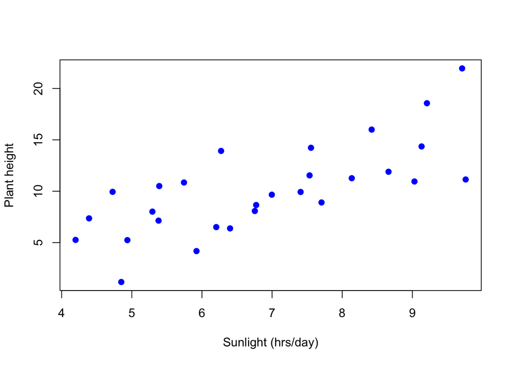

```r
plot(x = plant_height_df$Sunlight_hrs_per_day,
     y=plant_height_df$Plant_height,
     main = NULL,
     xlab = "Sunlight (hrs/day)",
     ylab = "Plant height", pch=19, col='blue')
```

### Calculation

- `cor()` - calculates correlation matrix between all features of dataframe

```r
cor(plant_height_df$Sunlight_hrs_per_day, plant_height_df$Plant_height)
```

```
## [1] 0.7294685
```

```r
# cor(iris %>%select(where(is.numeric)))
```

- `corr.test()` - also tests how far the coefficient is from zero *(t-test)*

```r
cor.test(plant_height_df$Sunlight_hrs_per_day,
         plant_height_df$Plant_height)
```

```
##
##  Pearson's product-moment correlation
##
## data:  plant_height_df$Sunlight_hrs_per_day and plant_height_df$Plant_height
## t = 5.4379, df = 26, p-value = 1.062e-05
## alternative hypothesis: true correlation is not equal to 0
## 95 percent confidence interval:
##  0.4896482 0.8666802
## sample estimates:
##       cor
## 0.7294685
```

## Example of 0 correlation

### 1

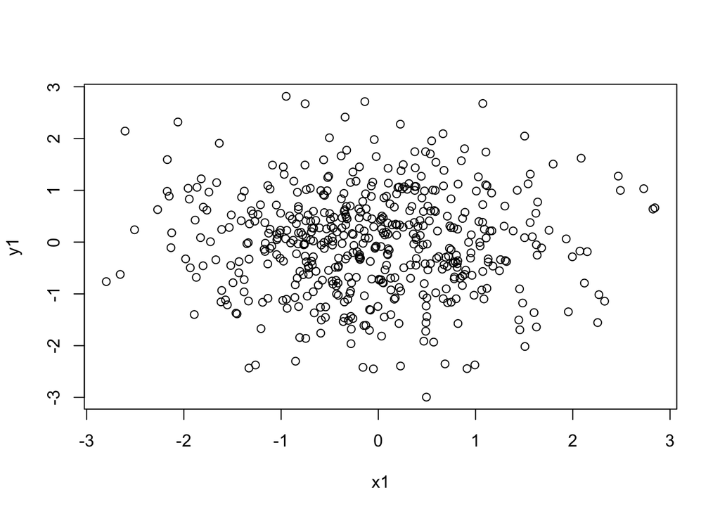

```r
x1=rnorm(500)
y1=rnorm(500)
plot(x1,y1)
```

```r
cor.test(x1, y1)
```

```
##
##  Pearson's product-moment correlation
##
## data:  x1 and y1
## t = -0.50239, df = 498, p-value = 0.6156
## alternative hypothesis: true correlation is not equal to 0
## 95 percent confidence interval:
##  -0.10998045  0.06531256
## sample estimates:
##         cor
## -0.02250693
```

### 2

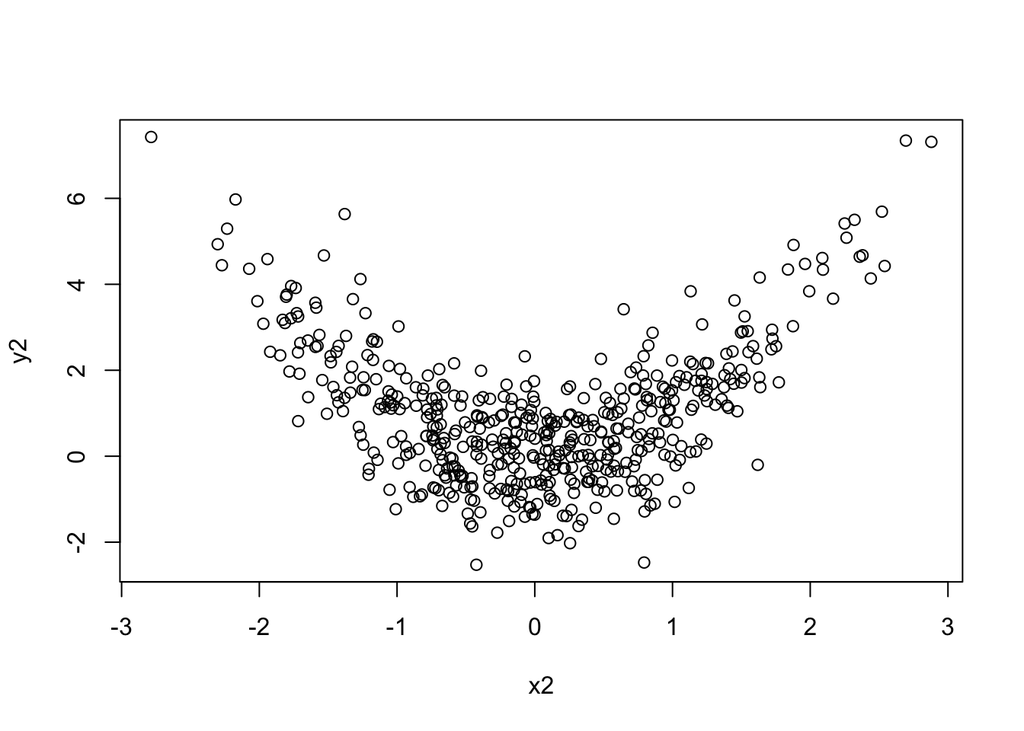

```r
x2=rnorm(500)
y2=x2^2 + rnorm(500, 0, 1)
plot(x2,y2)
```

```r
cor(x2, y2)
```

```
## [1] 0.05356488
```

> **That’s why you always should draw the scatterplot!**

### P.S

Game [**Guess the Correlation**](https://www.guessthecorrelation.com/)

# Ordinal vs ordinal | continuous vs ordinal

## Math and Physics Grades

```r
grades_math_phys = data.frame(math = c(5,2,3,4,6,1,9,10,2,5),
                             phys = c(4,2,3,1,2,2,8,8,2,4))
grades_math_phys
```

```
##    math phys
## 1     5    4
## 2     2    2
## 3     3    3
## 4     4    1
## 5     6    2
## 6     1    2
## 7     9    8
## 8    10    8
## 9     2    2
## 10    5    4
```

## Rank correlations

> The problems with Pearson correlation are that it is not suitable for “strange” non-linear relationships, non-normally distributed traits and data with outliers.

### Kendall’s $\tau$

- better when ranks are repeated

```r
cor(grades_math_phys, method = 'kendall')
```

```
##          math     phys
## math 1.000000 0.576624
## phys 0.576624 1.000000
```

### Spearman’s $\rho$

- Suitable for non-linear relationships
- Less sensitive to outliers
- Calculated based on ranks

```r
cor(grades_math_phys, method = 'spearman')
```

```
##           math      phys
## math 1.0000000 0.6775545
## phys 0.6775545 1.0000000
```

# Another usage of rank correlations

**For continuous data!**

## “Bad” Examples

- Non-linear

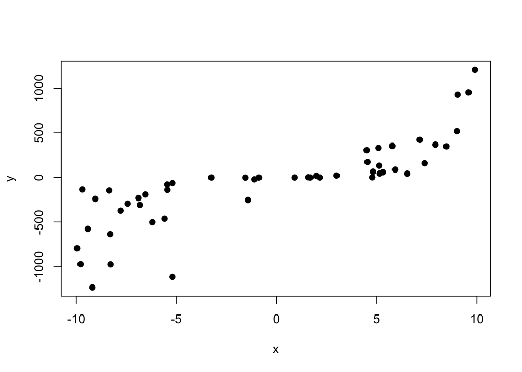

```r
x = runif(50, -10, 10)
y = (x + rnorm(50, 0, 2))^3
plot(x,y, pch=19)
```

```r
cor(x,y)
```

```
## [1] 0.8221853
```

```r
cor(x,y, method = "spearman")
```

```
## [1] 0.930084
```

```r
cor(x,y, method = "kendall")
```

```
## [1] 0.7844898
```

- With outliers

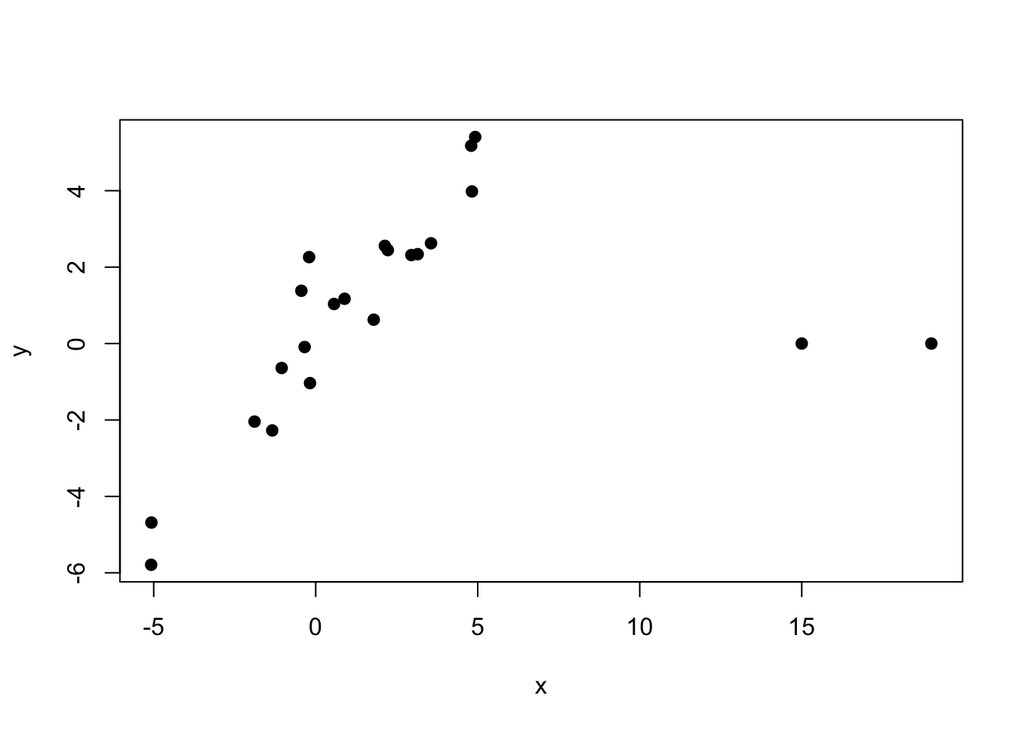

```r
x = c(rnorm(20,0,3), c(15, 19))
y = c(x[1:20] + c(rnorm(20,0,1)), 0, 0)
plot(x,y, pch=19)
```

```r
cor(x,y)
```

```
## [1] 0.396058
```

```r
cor.test(x,y, method = "spearman")
```

```
##
##  Spearman's rank correlation rho
##
## data:  x and y
## S = 500.64, p-value = 0.0001717
## alternative hypothesis: true rho is not equal to 0
## sample estimates:
##       rho
## 0.7173115
```

```r
# cor(x,y, method = "kendall")
```

# Always build a scatter-plot!

```r
cor.test(anscombe$x1, anscombe$y1, method = 'spearman')
```

```
##
##  Spearman's rank correlation rho
##
## data:  anscombe$x1 and anscombe$y1
## S = 40, p-value = 0.003734
## alternative hypothesis: true rho is not equal to 0
## sample estimates:
##       rho
## 0.8181818
```

```r
cor.test(anscombe$x2, anscombe$y2, method = 'spearman')
```

```
##
##  Spearman's rank correlation rho
##
## data:  anscombe$x2 and anscombe$y2
## S = 68, p-value = 0.02306
## alternative hypothesis: true rho is not equal to 0
## sample estimates:
##       rho
## 0.6909091
```

```r
cor.test(anscombe$x3, anscombe$y3, method = 'spearman')
```

```
##
##  Spearman's rank correlation rho
##
## data:  anscombe$x3 and anscombe$y3
## S = 2, p-value < 2.2e-16
## alternative hypothesis: true rho is not equal to 0
## sample estimates:
##       rho
## 0.9909091
```

```r
cor.test(anscombe$x4, anscombe$y4, method = 'spearman')
```

```
##
##  Spearman's rank correlation rho
##
## data:  anscombe$x4 and anscombe$y4
## S = 110, p-value = 0.1173
## alternative hypothesis: true rho is not equal to 0
## sample estimates:
## rho
## 0.5
```

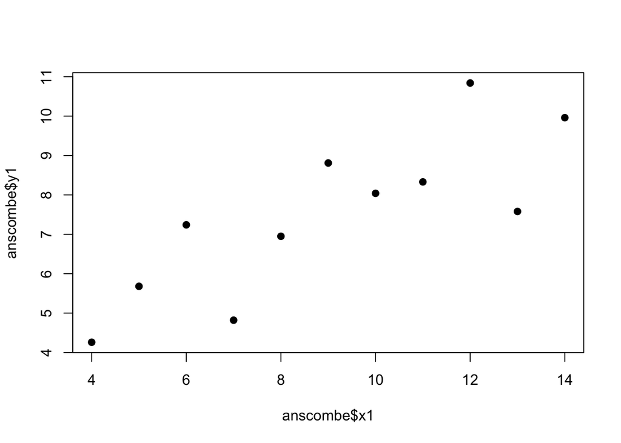

```r
plot(anscombe$x1, anscombe$y1, pch=19)
```

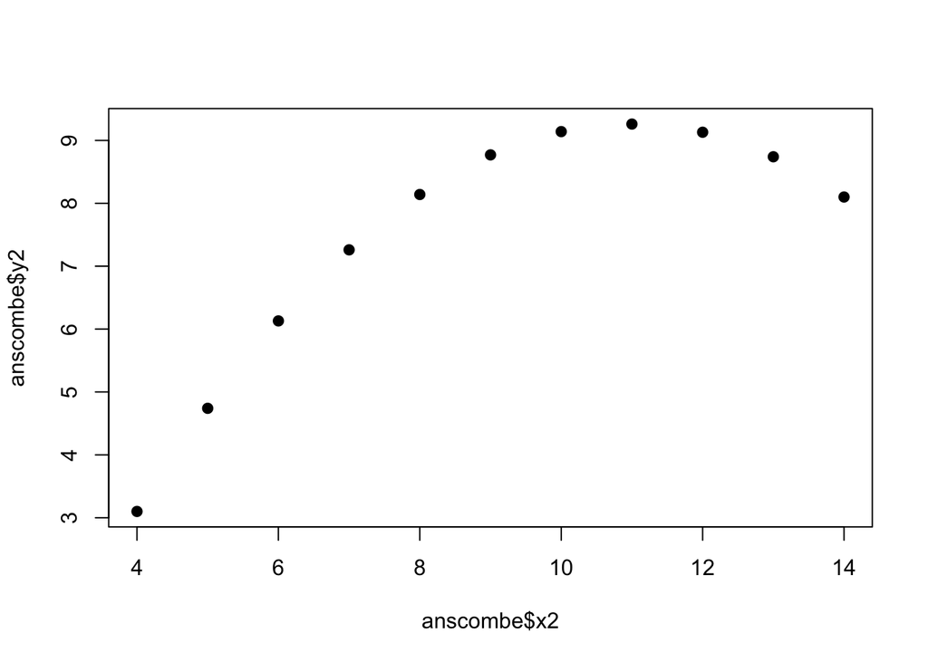

```r
plot(anscombe$x2, anscombe$y2, pch=19)
```

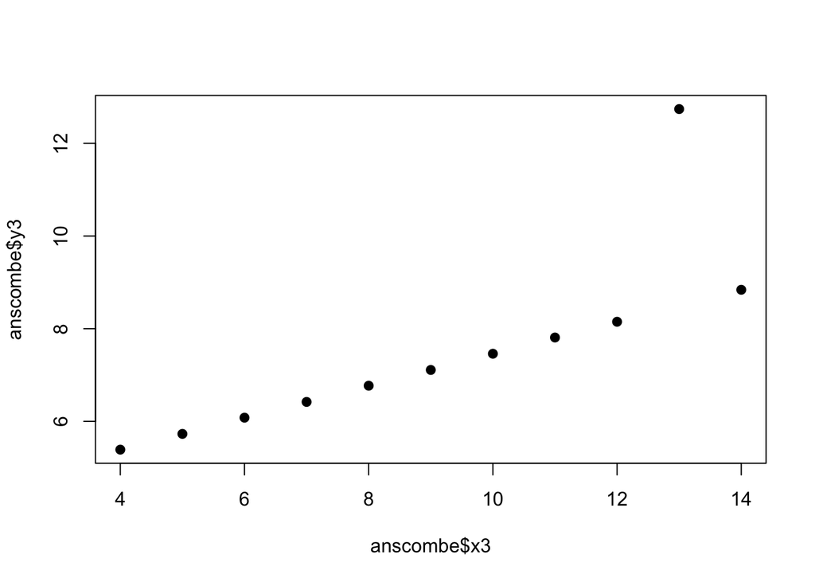

```r
plot(anscombe$x3, anscombe$y3, pch=19)
```

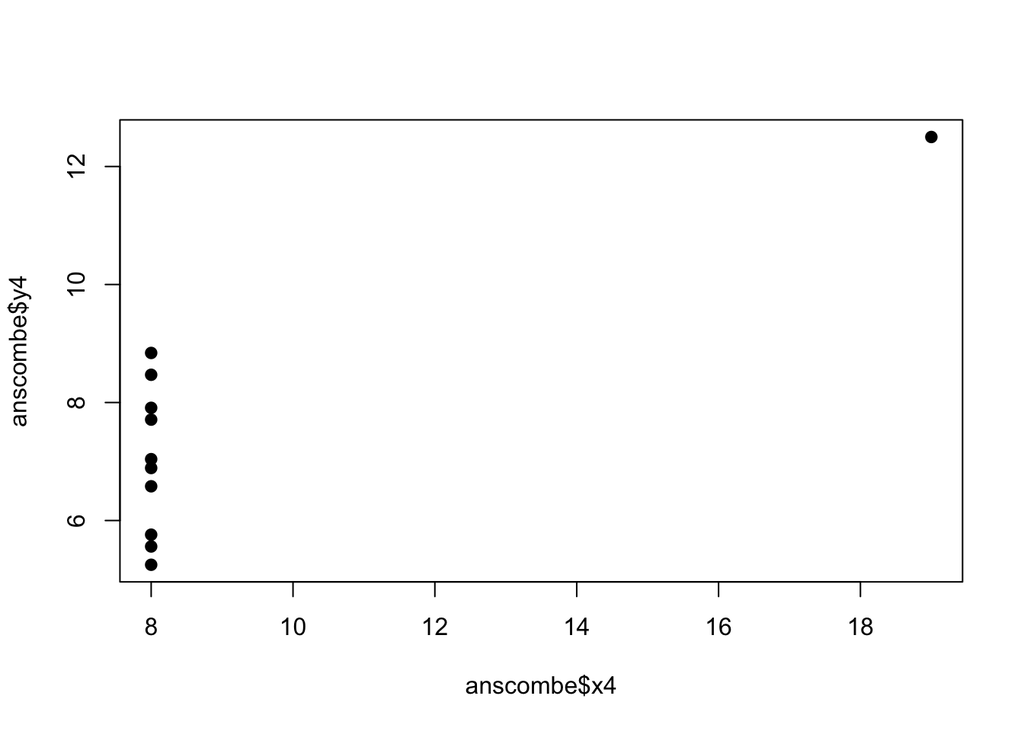

```r
plot(anscombe$x4, anscombe$y4, pch=19)
```

# Conclusions

1. **Correlation does not imply causation**
   - Website with numerous [spurious correlations](https://tylervigen.com/spurious-correlations)
2. **Correlation indicates presence of a relationship (association)**
3. **Absence of correlation indicates absence of a linear relationship**
4. **Absence of correlation does not indicate absence of a relationship (association)**

# Practice

## Arthritis dataset

```r
arth_df = read.csv('./data/Arthritis.csv',
                   stringsAsFactors = T)

arth_df |> glimpse(width = 80)
```

```
## Rows: 84
## Columns: 5
## $ ID        <int> 57, 46, 77, 17, 36, 23, 75, 39, 33, 55, 30, 5, 63, 83, 66, 4…
## $ Treatment <fct> Treated, Treated, Treated, Treated, Treated, Treated, Treate…
## $ Sex       <fct> Male, Male, Male, Male, Male, Male, Male, Male, Male, Male, …
## $ Age       <int> 27, 29, 30, 32, 46, 58, 59, 59, 63, 63, 64, 64, 69, 70, 23, …
## $ Improved  <fct> Marked, None, None, Marked, Marked, Marked, None, Marked, No…
```

```r
arth_df |> summary()
```

```
##        ID          Treatment      Sex          Age          Improved
##  Min.   : 1.00   Placebo:42   Female:49   Min.   :23.00   Marked:42
##  1st Qu.:21.75   Treated:42   Male  :35   1st Qu.:46.00   None  :42
##  Median :42.50                            Median :57.00
##  Mean   :42.50                            Mean   :53.36
##  3rd Qu.:63.25                            3rd Qu.:63.00
##  Max.   :84.00                            Max.   :74.00
```

> **Is it more likely to have “Marked Imporved” if you are female?**
> - dichotomous vs dichotomous

```r
cont_table = table(arth_df$Sex, arth_df$Improved)
cont_table_full = addmargins(cont_table)
cont_table_full
```

```
##
##          Marked None Sum
##   Female     30   19  49
##   Male       12   23  35
##   Sum        42   42  84
```

```r
risk_fem = cont_table_full['Female', 'Marked'] / cont_table_full['Female', 'Sum']
risk_fem
```

```
## [1] 0.6122449
```

```r
risk_male = cont_table_full['Male', 'Marked'] / cont_table_full['Male', 'Sum']
risk_male
```

```
## [1] 0.3428571
```

```r
RR = risk_fem / risk_male
RR
```

```
## [1] 1.785714
```

```r
RD = risk_fem - risk_male
RD
```

```
## [1] 0.2693878
```

```r
odds_fem = cont_table_full['Female', 'Marked'] / cont_table_full['Female', 'None']
odds_fem
```

```
## [1] 1.578947
```

```r
odds_male = cont_table_full['Male', 'Marked'] / cont_table_full['Male', 'None']
odds_male
```

```
## [1] 0.5217391
```

```r
OR = odds_fem / odds_male
OR
```

```
## [1] 3.026316
```

> **Is there a significant difference in the age of women and men?**
> - Continuous vs dichotomous

```r
MD = mean(arth_df |> filter(Sex == 'Male') |>  pull(Age) |>  mean()) -
          mean(arth_df |> filter(Sex == 'Female') |>  pull(Age) |>  mean())
MD
```

```
## [1] -0.3673469
```

```r
sexmean = arth_df |> group_by(Sex) |>  summarise(mean_age = mean(Age))
sexmean$mean_age[1] - sexmean$mean_age[2]
```

```
## [1] 0.3673469
```

## Diamonds dataset

```r
diamonds_small = diamonds |> slice_sample(n=1000)
diamonds_small |> str()
```

```
## tibble [1,000 × 10] (S3: tbl_df/tbl/data.frame)
##  $ carat  : num [1:1000] 0.27 0.77 0.31 0.35 0.51 1.7 0.38 1.27 0.37 0.7 ...
##  $ cut    : Ord.factor w/ 5 levels "Fair"<"Good"<..: 5 2 5 5 5 4 5 3 5 2 ...
##  $ color  : Ord.factor w/ 7 levels "D"<"E"<"F"<"G"<..: 3 3 6 3 1 6 5 7 1 3 ...
##  $ clarity: Ord.factor w/ 8 levels "I1"<"SI2"<"SI1"<..: 4 4 8 4 5 3 8 4 4 3 ...
##  $ depth  : num [1:1000] 60.9 60.3 61.3 61.4 62.1 58.6 60 61.8 61.1 63.7 ...
##  $ table  : num [1:1000] 57 61 57 54 55 59 60 60 56 58 ...
##  $ price  : int [1:1000] 577 2911 652 706 1959 8663 1064 5455 1050 2242 ...
##  $ x      : num [1:1000] 4.17 5.89 4.34 4.54 5.14 7.79 4.71 6.9 4.64 5.62 ...
##  $ y      : num [1:1000] 4.2 5.96 4.4 4.58 5.2 7.75 4.76 6.94 4.66 5.65 ...
##  $ z      : num [1:1000] 2.55 3.57 2.68 2.8 3.21 4.55 2.84 4.28 2.84 3.59 ...
```

```r
diamonds_small |> glimpse(width = 50)
```

```
## Rows: 1,000
## Columns: 10
## $ carat   <dbl> 0.27, 0.77, 0.31, 0.35, 0.51, 1.…
## $ cut     <ord> Ideal, Good, Ideal, Ideal, Ideal…
## $ color   <ord> F, F, I, F, D, I, H, J, D, F, D,…
## $ clarity <ord> VS2, VS2, IF, VS2, VS1, SI1, IF,…
## $ depth   <dbl> 60.9, 60.3, 61.3, 61.4, 62.1, 58…
## $ table   <dbl> 57, 61, 57, 54, 55, 59, 60, 60, …
## $ price   <int> 577, 2911, 652, 706, 1959, 8663,…
## $ x       <dbl> 4.17, 5.89, 4.34, 4.54, 5.14, 7.…
## $ y       <dbl> 4.20, 5.96, 4.40, 4.58, 5.20, 7.…
## $ z       <dbl> 2.55, 3.57, 2.68, 2.80, 3.21, 4.…
```

```r
diamonds_small |> summary()
```

```
##      carat               cut      color      clarity        depth
##  Min.   :0.2100   Fair     : 39   D:123   SI1    :247   Min.   :53.1
##  1st Qu.:0.3900   Good     : 82   E:193   VS2    :230   1st Qu.:61.1
##  Median :0.7000   Very Good:245   F:169   SI2    :179   Median :61.9
##  Mean   :0.7862   Premium  :250   G:196   VS1    :147   Mean   :61.8
##  3rd Qu.:1.0400   Ideal    :384   H:152   VVS2   : 77   3rd Qu.:62.6
##  Max.   :2.4600                   I:107   VVS1   : 76   Max.   :69.9
##                                   J: 60   (Other): 44
##      table           price               x               y
##  Min.   :53.00   Min.   :  353.0   Min.   :3.890   Min.   :3.860
##  1st Qu.:56.00   1st Qu.:  958.5   1st Qu.:4.700   1st Qu.:4.710
##  Median :57.00   Median : 2302.0   Median :5.660   Median :5.690
##  Mean   :57.47   Mean   : 3777.6   Mean   :5.711   Mean   :5.712
##  3rd Qu.:59.00   3rd Qu.: 5245.8   3rd Qu.:6.522   3rd Qu.:6.520
##  Max.   :68.00   Max.   :18663.0   Max.   :8.660   Max.   :8.600
##
##        z
##  Min.   :2.29
##  1st Qu.:2.89
##  Median :3.52
##  Mean   :3.53
##  3rd Qu.:4.04
##  Max.   :5.44
##
```

> Are there some associated variables?
> - continuous vs continuous
> - ordinal vs ordinal (not forget -> `as.numeric()`)

```r
cor.test(diamonds_small$clarity, diamonds_small$price)
```

[output not shown]

```r
cor(diamonds_small$price,
    diamonds_small$cut |>  as.numeric(),
    method='spearman')
```

```
## [1] -0.06406712
```